# Resolución Actividad 3-Grupal Máster Bioinformática UNIR (2025)

## 3.9 Gráfico 9: Gráfico de PCA de tratamientos

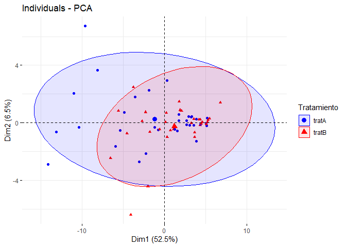

```r
# **New Plot: Visualizar individuos por tratamiento**
# For this to work, ensure 'datos' has a column named 'trat'
# or create a 'df' dataframe with a 'trat' column that aligns with your 'genes' data.
# For example, if your 'datos' dataframe contains a 'trat' column:
if ("trat" %in% colnames(datos)) {
  fviz_pca_ind(pca_result, geom.ind = "point", col.ind = datos$trat,
               palette = c("blue", "red"), addEllipses = TRUE, legend.title = "Tratamiento")
} else {
  message("Warning: 'trat' column not found in 'datos' dataframe. Cannot color individuals by treatment.")
  message("Please ensure your 'datos' dataframe contains a 'trat' column or create 'df$trat' appropriately.")
}
```

Los resultados de un Análisis de Componentes Principales (PCA) se han visualizado para examinar la distribución de individuos, agrupados por dos tratamientos: “tratA”, simbolizado por puntos azules, y “tratB”, representado por triángulos rojos. La proyección de los individuos se realizó sobre el plano definido por las dos primeras componentes principales, Dim1 y Dim2. Dim1, la primera componente, explica el 52.5% de la varianza total de los datos, mientras que Dim2 explica el 6.5%. Esta distribución de la varianza subraya la predominancia de Dim1 en la explicación de las diferencias observadas entre los individuos. Para evaluar la separación y la variabilidad inherente a cada grupo de tratamiento, se han dibujado elipses de confianza alrededor de cada uno, asumiendo un nivel de confianza estándar, comúnmente del 95%.

Una observación crucial es el considerable solapamiento entre las elipses de confianza correspondientes a “tratA” (azul) y “tratB” (rojo). Este solapamiento sugiere que, a pesar de la existencia de dos grupos de tratamiento distintos, la diferenciación general entre ellos no es marcadamente discernible a lo largo de las dos primeras componentes principales. La implicación es que una parte significativa de los individuos de un grupo reside dentro del rango de variabilidad del otro, lo que dificulta una separación clara. En cuanto a la distribución de los individuos, se aprecia que los de “tratA” (puntos azules) muestran una mayor dispersión a lo largo de Dim1, ocupando un rango más amplio de valores en esta componente en comparación con “tratB”; notablemente, algunos puntos azules se extienden hacia la región negativa de Dim1. Por otro lado, los individuos de “tratB” (triángulos rojos) tienden a concentrarse ligeramente más en la zona central del gráfico, aunque también exhiben una considerable variabilidad.

En lo que respecta al significado de las dimensiones, Dim1, que explica el 52.5% de la varianza, es la componente más informativa. Cualquier patrón de separación o diferenciación que se observe a lo largo de este eje es el más relevante. A pesar del solapamiento, las diferencias en la distribución de los puntos a lo largo de Dim1 podrían señalar características o patrones en los datos que varían más entre los tratamientos. Por ejemplo, los individuos de “tratA” ubicados en el extremo negativo de Dim1 podrían poseer atributos únicos que los distinguen. Por el contrario, Dim2, que explica solo el 6.5% de la varianza, tiene una influencia mucho menor en la distinción general entre los tratamientos; los patrones o diferencias que se manifiestan a lo largo de este eje son, por ende, menos pronunciados.

# 4 Tablas Descriptivas de PCA, en terciles.

Los 5 componenetes seleccionados del PCA explican el 72.3% de los datos, por lotanto serían una tabla por cada componente:

```r
library(knitr)
# ============================================================================
# 1. CALCULAR TERCILES PARA LOS COMPONENTES PRINCIPALES
# ============================================================================

# Extraer las puntuaciones de los PC ( solo los que explican >70% varianza)
pca_scores <- as.data.frame(pca_result$x[, 1:n.pc])

# funcion calcular terciles
calcular_terciles <- function(x) {
  quantiles <- quantile(x, probs = c(0, 1/3, 2/3, 1), na.rm = TRUE)
  cut(x, breaks = quantiles, labels = c("T1", "T2", "T3"), include.lowest = TRUE)
}

# terciles para cada componente principal
for(i in 1:n.pc) {
  col_name <- paste0("PC", i, "_tercil")
  pca_scores[[col_name]] <- calcular_terciles(pca_scores[[paste0("PC", i)]])
}

# ============================================================================
# 2. COMBINAR CON DATOS ORIGINALES
# ============================================================================

# Combinar las puntuaciones PCA con terciles y los datos originales de genes
datos_completos <- cbind(genes, pca_scores)

# Seleccionar variables importantes de genes (ajustables)
vars_importantes <- names(genes)[1:min(46, ncol(genes))]

# ============================================================================
# CREAR TABLAS DESCRIPTIVAS PARA TODOS LOS COMPONENTES PRINCIPALES
# ============================================================================

# Crear una función para generar cada tabla
generar_tabla_pc_completa <- function(i, umbral_cientifico = 0.001) {
  var_tercil <- paste0("PC", i, "_tercil")

  if(var_tercil %in% names(datos_completos)) {
    datos_completos %>%
      select(all_of(vars_importantes), all_of(var_tercil)) %>%
      tbl_summary(
        by = all_of(var_tercil),
        statistic = all_continuous() ~ "{mean} ({sd})",
         digits = all_continuous() ~ function(x) format(x, digits = 2, scientific = TRUE),
        missing = "no"
      ) %>%
      add_p(test = all_continuous() ~ "aov") %>%
      modify_fmt_fun(
        update = list(
          all_stat_cols() ~ function(x) {
            nums <- as.numeric(unlist(regmatches(x, gregexpr("\\d+\\.\\d+", x))))
            if(length(nums) > 0) {
              formatted_nums <- ifelse(abs(nums) < umbral_cientifico & nums != 0,
                                     formatC(nums, format = "e", digits = 2),
                                     formatC(nums, format = "f", digits = 3))
              if(length(formatted_nums) == 2) {
                paste0(formatted_nums[1], " (", formatted_nums[2], ")")
              } else {
                x
              }
            } else {
              x
            }
          },
          p.value ~ function(x) {
            ifelse(x < umbral_cientifico,
                   formatC(x, format = "e", digits = 2),
                   formatC(x, format = "f", digits = 3))
          }
        )
      ) %>%
      modify_header(label ~ "**Gen**") %>%
      modify_spanning_header(
        c("stat_1", "stat_2", "stat_3") ~ paste0("**Componente Principal ", i, "**")
      ) %>%
      modify_caption(paste0("**Tabla descriptiva por terciles - Componente Principal ", i, "**")) %>%
      modify_footnote(
        update = everything() ~ paste0("Nota: Media (desviación estándar). Valores < ", umbral_cientifico, " mostrados en notación científica.")
      )
  } else {
    return(NULL)
  }
}

# Generar tablas con control total del formato
for(i in 1:n.pc) {
  tabla <- generar_tabla_pc_completa(i, umbral_cientifico = 0.001)
  if(!is.null(tabla)) {
    cat("\n\n## Componente Principal", i, "\n\n")
    print(tabla)
    cat("\n\n")
  }
}
```

## 4.1 Componente Principal 1

**Tabla descriptiva por terciles - Componente Principal 1**

| **Gen**<sup>1</sup> | **Componente Principal 1** **T1** N = 22<sup>1</sup> | **Componente Principal 1** **T2** N = 21<sup>1</sup> | **Componente Principal 1** **T3** N = 22<sup>1</sup> | **p-value**<sup>1</sup> |  |
| --- | --- | --- | --- | --- | --- |
| AQ_ADIPOQ | 2.3e-09 (5.5e-09) | 4.2e-10 (5.4e-10) | 4.5e-02 (2.1e-01) |  | 0.382 |
| AQ_ALOX5 | 1.4e-04 (6.9e-05) | 5.1e-05 (3.6e-05) | 2.1e-05 (1.5e-05) | 3.16e-11 |  |
| AQ_ARG1 | 6.8e-06 (7e-06) | 2.9e-06 (3.5e-06) | 2.4e-06 (3.6e-06) | 0.009 |  |
| AQ_BMP2 | 1e-07 (7.6e-08) | 4e-08 (4e-08) | 2e-08 (3.2e-08) | 9.78e-06 |  |
| AQ_CCL2 | 2.5e-07 (2.9e-07) | 9e-08 (1.4e-07) | 1.5e-08 (1.3e-08) | 4.08e-04 |  |
| AQ_CCL5 | 1.1e-03 (5.9e-04) | 3.6e-04 (2.3e-04) | 1.2e-04 (7.1e-05) | 9.14e-12 |  |
| AQ_CCR5 | 1.9e-05 (1.2e-05) | 6.6e-06 (3.2e-06) | 2.2e-06 (1.7e-06) | 4.88e-10 |  |
| AQ_CD274 | 3.7e-06 (2e-06) | 1.5e-06 (1.4e-06) | 5.3e-07 (3.9e-07) | 1.32e-09 |  |
| AQ_CD36 | 5e-05 (1.9e-05) | 2.8e-05 (1.8e-05) | 7.9e-06 (5.1e-06) | 2.56e-12 |  |
| AQ_CHKA | 1.2e-06 (9.7e-07) | 7e-07 (5.1e-07) | 2.8e-07 (4e-07) | 8.77e-05 |  |
| AQ_CPT1A | 1.8e-05 (9.5e-06) | 7.1e-06 (5.1e-06) | 2.4e-06 (1.8e-06) | 7.43e-11 |  |
| AQ_CSF2 | 4.8e-08 (4.6e-08) | 3.4e-08 (4.1e-08) | 7.2e-09 (1.2e-08) | 0.001 |  |
| AQ_CXCR1 | 3.8e-05 (2.6e-05) | 1.2e-05 (8e-06) | 5e-06 (3.2e-06) | 1.15e-08 |  |
| AQ_FASN | 8.3e-06 (4.3e-06) | 3.4e-06 (1.3e-06) | 7.5e-07 (5.6e-07) | 3.80e-13 |  |
| AQ_FOXO3 | 2.9e-04 (1.7e-04) | 1.8e-04 (1.5e-04) | 8e-05 (4.5e-05) | 1.41e-05 |  |
| AQ_FOXP3 | 3.5e-06 (3.2e-06) | 1.2e-06 (5.7e-07) | 2.6e-07 (2e-07) | 1.39e-06 |  |
| AQ_G6PD | 7.8e-05 (3.8e-05) | 3.5e-05 (1.2e-05) | 1.4e-05 (8.8e-06) | 4.73e-12 |  |
| AQ_GPD2 | 5.1e-06 (3.3e-06) | 1.7e-06 (1.2e-06) | 7.8e-07 (6.1e-07) | 6.89e-09 |  |
| AQ_GPX1 | 1.4e-04 (6.5e-05) | 9.1e-05 (5.2e-05) | 6.1e-05 (3.6e-05) | 4.64e-05 |  |
| AQ_IFNG | 6.8e-07 (5.4e-07) | 2.4e-07 (1.4e-07) | 8.6e-08 (1e-07) | 3.24e-07 |  |
| AQ_IL10 | 2.1e-07 (2.9e-07) | 7.4e-08 (1.1e-07) | 1.6e-08 (1.4e-08) | 0.002 |  |
| AQ_IL1B | 2.8e-05 (1.9e-05) | 9.4e-06 (5.9e-06) | 3.2e-06 (2.8e-06) | 4.23e-09 |  |
| AQ_IL6 | 6.5e-08 (7.7e-08) | 1.8e-08 (1.9e-08) | 8.5e-09 (1.4e-08) | 2.75e-04 |  |
| AQ_IRS1 | 2.2e-07 (1.3e-07) | 1.3e-07 (7.6e-08) | 4.5e-08 (2.6e-08) | 3.28e-08 |  |
| AQ_JAK1 | 2.2e-04 (9e-05) | 8.8e-05 (2.7e-05) | 2.8e-05 (1.5e-05) | 2.83e-16 |  |
| AQ_JAK3 | 6.3e-05 (5.3e-05) | 1.9e-05 (1.1e-05) | 6.8e-06 (5.3e-06) | 3.39e-07 |  |
| AQ_LDHA | 5.4e-05 (2.2e-05) | 2.7e-05 (1.3e-05) | 1e-05 (6.6e-06) | 1.65e-12 |  |
| AQ_LIF | 4.1e-08 (4.7e-08) | 1.9e-08 (2.2e-08) | 5.4e-09 (5.8e-09) | 8.89e-04 |  |
| AQ_MAPK1 | 5.3e-05 (2.1e-05) | 2.1e-05 (1.1e-05) | 8e-06 (6.4e-06) | 2.67e-15 |  |
| AQ_NFE2L2 | 6.3e-05 (2.8e-05) | 2.1e-05 (1.3e-05) | 8.7e-06 (7.3e-06) | 3.29e-14 |  |
| AQ_NFKB1 | 3.1e-05 (1e-05) | 1.3e-05 (7.7e-06) | 3.2e-06 (3.4e-06) | 1.18e-17 |  |
| AQ_NLRP3 | 1.3e-05 (6.5e-06) | 5.2e-06 (2.7e-06) | 1.6e-06 (8.6e-07) | 4.13e-13 |  |
| AQ_NOS2 | 6.1e-09 (7.9e-09) | 2.5e-09 (3.2e-09) | 7.1e-10 (1.4e-09) | 0.002 |  |
| AQ_NOX5 | 6e-09 (1.2e-08) | 4.8e-09 (8.2e-09) | 4.5e-02 (2.1e-01) | 0.382 |  |
| AQ_PDCD1 | 3.7e-06 (3.4e-06) | 9.8e-07 (5e-07) | 3.5e-07 (3.9e-07) | 1.34e-06 |  |
| AQ_PPARG | 3.1e-07 (3e-07) | 1e-07 (1e-07) | 1.6e-08 (1.5e-08) | 5.81e-06 |  |
| AQ_PTAFR | 9e-05 (3.1e-05) | 3.2e-05 (1.5e-05) | 1.5e-05 (6.9e-06) | 3.32e-18 |  |
| AQ_PTGS2 | 9.1e-06 (5.2e-06) | 3.7e-06 (2.2e-06) | 1.8e-06 (9e-07) | 1.71e-09 |  |
| AQ_SLC2A4 | 2.4e-07 (3e-07) | 1.6e-07 (1.3e-07) | 1.8e-07 (1.4e-07) | 0.412 |  |
| AQ_SOD1 | 3.7e-05 (2.3e-05) | 1.8e-05 (9.8e-06) | 5.9e-06 (4.9e-06) | 8.37e-09 |  |
| AQ_SREBF1 | 1.7e-05 (5.8e-06) | 7e-06 (2.8e-06) | 2.3e-06 (1.3e-06) | 4.39e-18 |  |
| AQ_STAT3 | 7.3e-05 (5.3e-05) | 3.1e-05 (1.9e-05) | 9.3e-06 (9.2e-06) | 1.25e-07 |  |
| AQ_TGFB1 | 5.2e-04 (3e-04) | 2.3e-04 (1.2e-04) | 7.1e-05 (3.8e-05) | 2.16e-10 |  |
| AQ_TLR3 | 9.1e-07 (9.6e-07) | 3.6e-07 (2.2e-07) | 5.9e-08 (7.2e-08) | 3.32e-05 |  |
| AQ_TLR4 | 3.7e-05 (1.9e-05) | 1.3e-05 (9.9e-06) | 6.3e-06 (5.2e-06) | 3.74e-11 |  |
| AQ_TNF | 2.2e-05 (1.3e-05) | 8.7e-06 (5.6e-06) | 2.2e-06 (1.6e-06) | 6.89e-11 |  |

<sup>1</sup> Nota: Media (desviación estándar). Valores < 0.001 mostrados en notación científica.

## 4.2 Componente Principal 2

**Tabla descriptiva por terciles - Componente Principal 2**

| **Gen**<sup>1</sup> | **Componente Principal 2** **T1** N = 22<sup>1</sup> | **Componente Principal 2** **T2** N = 21<sup>1</sup> | **Componente Principal 2** **T3** N = 22<sup>1</sup> | **p-value**<sup>1</sup> |  |
| --- | --- | --- | --- | --- | --- |
| AQ_ADIPOQ | 8.6e-10 (1e-09) | 3.5e-10 (3.8e-10) | 4.5e-02 (2.1e-01) |  | 0.382 |
| AQ_ALOX5 | 1e-04 (7.2e-05) | 3.5e-05 (3.4e-05) | 7.1e-05 (7e-05) | 0.003 |  |
| AQ_ARG1 | 8.4e-06 (6.8e-06) | 1.8e-06 (1.7e-06) | 1.8e-06 (2.8e-06) | 1.72e-06 |  |
| AQ_BMP2 | 8.1e-08 (7.1e-08) | 3.1e-08 (6.2e-08) | 4.9e-08 (4.6e-08) | 0.029 |  |
| AQ_CCL2 | 9.1e-08 (1.2e-07) | 4.6e-08 (7e-08) | 2.1e-07 (3.2e-07) | 0.021 |  |
| AQ_CCL5 | 6.9e-04 (5e-04) | 2.8e-04 (4.3e-04) | 5.7e-04 (6.2e-04) | 0.041 |  |
| AQ_CCR5 | 1.1e-05 (1.1e-05) | 3.5e-06 (2.8e-06) | 1.3e-05 (1.2e-05) | 0.005 |  |
| AQ_CD274 | 3e-06 (2.6e-06) | 1.1e-06 (1.2e-06) | 1.6e-06 (1.2e-06) | 0.003 |  |
| AQ_CD36 | 4.2e-05 (2.5e-05) | 1.2e-05 (9.4e-06) | 3.1e-05 (2.2e-05) | 3.67e-05 |  |
| AQ_CHKA | 8.8e-07 (6.3e-07) | 3.3e-07 (4e-07) | 9.9e-07 (1e-06) | 0.009 |  |
| AQ_CPT1A | 1.1e-05 (8e-06) | 4.3e-06 (4.2e-06) | 1.2e-05 (1.2e-05) | 0.009 |  |
| AQ_CSF2 | 3.1e-08 (3.8e-08) | 1.8e-08 (3.4e-08) | 4e-08 (4.5e-08) | 0.185 |  |
| AQ_CXCR1 | 3.1e-05 (2.6e-05) | 8.7e-06 (1.6e-05) | 1.5e-05 (1.4e-05) | 7.30e-04 |  |
| AQ_FASN | 4.5e-06 (3.4e-06) | 2e-06 (3e-06) | 5.8e-06 (4.7e-06) | 0.006 |  |
| AQ_FOXO3 | 2.8e-04 (2e-04) | 1.3e-04 (8.7e-05) | 1.4e-04 (1.2e-04) | 0.001 |  |
| AQ_FOXP3 | 1.5e-06 (1.3e-06) | 6.8e-07 (1.2e-06) | 2.7e-06 (3.3e-06) | 0.014 |  |
| AQ_G6PD | 6.3e-05 (4e-05) | 2.3e-05 (2.1e-05) | 4e-05 (3.3e-05) | 6.17e-04 |  |
| AQ_GPD2 | 2.8e-06 (2.3e-06) | 1.2e-06 (1.4e-06) | 3.5e-06 (3.7e-06) | 0.018 |  |
| AQ_GPX1 | 1.3e-04 (5.9e-05) | 9.1e-05 (6.5e-05) | 7.2e-05 (4.5e-05) | 0.009 |  |
| AQ_IFNG | 4.4e-07 (4.9e-07) | 1.6e-07 (1.9e-07) | 4.1e-07 (4.4e-07) | 0.047 |  |
| AQ_IL10 | 1.9e-07 (3.1e-07) | 3.3e-08 (3.6e-08) | 7.1e-08 (7.8e-08) | 0.018 |  |
| AQ_IL1B | 2.3e-05 (2.1e-05) | 7.6e-06 (1.2e-05) | 1e-05 (8.4e-06) | 0.003 |  |
| AQ_IL6 | 3.6e-08 (5.4e-08) | 2.6e-08 (6.6e-08) | 2.9e-08 (3.6e-08) | 0.817 |  |
| AQ_IRS1 | 1.7e-07 (1.3e-07) | 8.2e-08 (8e-08) | 1.4e-07 (1.2e-07) | 0.036 |  |
| AQ_JAK1 | 1.3e-04 (8e-05) | 6.5e-05 (9.7e-05) | 1.4e-04 (1e-04) | 0.025 |  |
| AQ_JAK3 | 4.6e-05 (5.8e-05) | 1.2e-05 (1.2e-05) | 3.1e-05 (2.4e-05) | 0.017 |  |
| AQ_LDHA | 3.5e-05 (2.4e-05) | 1.5e-05 (1.3e-05) | 4e-05 (2.5e-05) | 9.12e-04 |  |
| AQ_LIF | 1.5e-08 (2.6e-08) | 1.1e-08 (1.5e-08) | 3.9e-08 (4.5e-08) | 0.012 |  |
| AQ_MAPK1 | 4.3e-05 (2.7e-05) | 1.3e-05 (1.4e-05) | 2.6e-05 (1.9e-05) | 7.97e-05 |  |
| AQ_NFE2L2 | 4.4e-05 (3e-05) | 1.8e-05 (2.2e-05) | 2.9e-05 (3e-05) | 0.011 |  |
| AQ_NFKB1 | 2.1e-05 (1.1e-05) | 7.4e-06 (1.3e-05) | 1.8e-05 (1.4e-05) | 0.002 |  |
| AQ_NLRP3 | 9e-06 (6.9e-06) | 3.4e-06 (3.9e-06) | 7.7e-06 (6.8e-06) | 0.010 |  |
| AQ_NOS2 | 4.4e-09 (6.3e-09) | 1.9e-09 (4.7e-09) | 3e-09 (5.2e-09) | 0.346 |  |
| AQ_NOX5 | 7.4e-09 (1.3e-08) | 2.1e-09 (4.2e-09) | 4.5e-02 (2.1e-01) | 0.382 |  |
| AQ_PDCD1 | 1.9e-06 (2.4e-06) | 5.7e-07 (5.6e-07) | 2.6e-06 (3.3e-06) | 0.022 |  |
| AQ_PPARG | 2.8e-07 (3.1e-07) | 5.4e-08 (9.3e-08) | 8.9e-08 (8.7e-08) | 5.48e-04 |  |
| AQ_PTAFR | 6.9e-05 (3.6e-05) | 2.8e-05 (3.2e-05) | 3.9e-05 (3.4e-05) | 5.56e-04 |  |
| AQ_PTGS2 | 6.6e-06 (3.7e-06) | 3.2e-06 (3.6e-06) | 4.8e-06 (5.6e-06) | 0.047 |  |
| AQ_SLC2A4 | 2.9e-07 (3e-07) | 1.9e-07 (9.8e-08) | 1e-07 (1e-07) | 0.006 |  |
| AQ_SOD1 | 2.4e-05 (1.9e-05) | 1.4e-05 (1.7e-05) | 2.3e-05 (2.2e-05) | 0.203 |  |
| AQ_SREBF1 | 1e-05 (5.5e-06) | 5.1e-06 (6.9e-06) | 1e-05 (7.7e-06) | 0.016 |  |
| AQ_STAT3 | 4.8e-05 (4.9e-05) | 2e-05 (2.6e-05) | 4.5e-05 (4.5e-05) | 0.065 |  |
| AQ_TGFB1 | 3.8e-04 (2.7e-04) | 1.6e-04 (2.1e-04) | 2.8e-04 (2.6e-04) | 0.021 |  |
| AQ_TLR3 | 6.8e-07 (8.9e-07) | 1.8e-07 (3.8e-07) | 4.6e-07 (5.5e-07) | 0.049 |  |
| AQ_TLR4 | 3.1e-05 (2.1e-05) | 1e-05 (1.1e-05) | 1.6e-05 (1.5e-05) | 3.15e-04 |  |
| AQ_TNF | 1.6e-05 (1.5e-05) | 4.9e-06 (5.7e-06) | 1.2e-05 (9.8e-06) | 0.006 |  |

<sup>1</sup> Nota: Media (desviación estándar). Valores < 0.001 mostrados en notación científica.

## 4.3 Componente Principal 3

**Tabla descriptiva por terciles - Componente Principal 3**

| **Gen**<sup>1</sup> | **Componente Principal 3** **T1** N = 22<sup>1</sup> | **Componente Principal 3** **T2** N = 21<sup>1</sup> | **Componente Principal 3** **T3** N = 22<sup>1</sup> | **p-value**<sup>1</sup> |  |
| --- | --- | --- | --- | --- | --- |
| AQ_ADIPOQ | 4.5e-02 (2.1e-01) | 1.6e-09 (5.7e-09) | 7.1e-10 (9.6e-10) |  | 0.382 |
| AQ_ALOX5 | 7.8e-05 (7e-05) | 4.6e-05 (5.5e-05) | 8.4e-05 (7e-05) | 0.135 |  |
| AQ_ARG1 | 3.1e-06 (5.9e-06) | 3.1e-06 (4e-06) | 5.9e-06 (5.7e-06) | 0.149 |  |
| AQ_BMP2 | 4.4e-08 (4.1e-08) | 4.5e-08 (5.4e-08) | 7.2e-08 (8.4e-08) | 0.260 |  |
| AQ_CCL2 | 1.4e-07 (2.8e-07) | 1.2e-07 (1.8e-07) | 1e-07 (1.5e-07) | 0.850 |  |
| AQ_CCL5 | 4.1e-04 (4.5e-04) | 3.1e-04 (3.4e-04) | 8.2e-04 (6.6e-04) | 0.003 |  |
| AQ_CCR5 | 8.5e-06 (8.6e-06) | 6.2e-06 (6.4e-06) | 1.3e-05 (1.3e-05) | 0.083 |  |
| AQ_CD274 | 1.9e-06 (1.9e-06) | 1.3e-06 (1.1e-06) | 2.6e-06 (2.5e-06) | 0.115 |  |
| AQ_CD36 | 2.3e-05 (2.1e-05) | 2.3e-05 (1.9e-05) | 4.1e-05 (2.5e-05) | 0.011 |  |
| AQ_CHKA | 3.4e-07 (4.4e-07) | 6.9e-07 (6.6e-07) | 1.2e-06 (9.1e-07) | 7.01e-04 |  |
| AQ_CPT1A | 6.8e-06 (8.5e-06) | 6.7e-06 (6.4e-06) | 1.4e-05 (1e-05) | 0.011 |  |
| AQ_CSF2 | 2.8e-08 (3.8e-08) | 2.5e-08 (3.3e-08) | 3.6e-08 (4.8e-08) | 0.643 |  |
| AQ_CXCR1 | 1.9e-05 (2.3e-05) | 1.2e-05 (1.4e-05) | 2.4e-05 (2.4e-05) | 0.202 |  |
| AQ_FASN | 3.5e-06 (3.2e-06) | 3.5e-06 (4e-06) | 5.4e-06 (4.7e-06) | 0.220 |  |
| AQ_FOXO3 | 9.9e-05 (1.1e-04) | 1.3e-04 (5.8e-05) | 3.2e-04 (1.7e-04) | 1.98e-07 |  |
| AQ_FOXP3 | 1.9e-06 (3.3e-06) | 1.3e-06 (1.7e-06) | 1.7e-06 (1.5e-06) | 0.674 |  |
| AQ_G6PD | 3.8e-05 (2.7e-05) | 2.6e-05 (2.1e-05) | 6.3e-05 (4.5e-05) | 0.002 |  |
| AQ_GPD2 | 2.2e-06 (2.2e-06) | 1.8e-06 (1.9e-06) | 3.5e-06 (3.7e-06) | 0.096 |  |
| AQ_GPX1 | 6.8e-05 (4.9e-05) | 7.8e-05 (3.8e-05) | 1.4e-04 (6.4e-05) | 2.48e-05 |  |
| AQ_IFNG | 2.9e-07 (4e-07) | 2.2e-07 (2.8e-07) | 4.9e-07 (4.9e-07) | 0.079 |  |
| AQ_IL10 | 1.6e-07 (3.1e-07) | 4.8e-08 (5.1e-08) | 9e-08 (9.2e-08) | 0.162 |  |
| AQ_IL1B | 1.7e-05 (2.2e-05) | 7.8e-06 (7.6e-06) | 1.5e-05 (1.2e-05) | 0.110 |  |
| AQ_IL6 | 2.4e-08 (4.4e-08) | 2.6e-08 (4.1e-08) | 4.1e-08 (6.8e-08) | 0.519 |  |
| AQ_IRS1 | 1.2e-07 (1e-07) | 1e-07 (9.1e-08) | 1.7e-07 (1.4e-07) | 0.129 |  |
| AQ_JAK1 | 1.1e-04 (9.5e-05) | 8.3e-05 (7.5e-05) | 1.4e-04 (1.1e-04) | 0.119 |  |
| AQ_JAK3 | 4e-05 (5.8e-05) | 2.4e-05 (2.8e-05) | 2.5e-05 (2e-05) | 0.307 |  |
| AQ_LDHA | 3.1e-05 (2.5e-05) | 2.5e-05 (2.1e-05) | 3.5e-05 (2.5e-05) | 0.368 |  |
| AQ_LIF | 1.3e-08 (2.6e-08) | 2.6e-08 (3.8e-08) | 2.6e-08 (3.5e-08) | 0.358 |  |
| AQ_MAPK1 | 2.1e-05 (2.1e-05) | 1.9e-05 (1.7e-05) | 4.2e-05 (2.6e-05) | 8.12e-04 |  |
| AQ_NFE2L2 | 2.6e-05 (3e-05) | 2.3e-05 (2.4e-05) | 4.3e-05 (3.1e-05) | 0.052 |  |
| AQ_NFKB1 | 1.3e-05 (1.4e-05) | 1.2e-05 (1.2e-05) | 2.1e-05 (1.5e-05) | 0.065 |  |
| AQ_NLRP3 | 7.6e-06 (7.7e-06) | 4.8e-06 (4.3e-06) | 7.8e-06 (6.6e-06) | 0.242 |  |
| AQ_NOS2 | 5.5e-09 (8.1e-09) | 1.5e-09 (2.5e-09) | 2.3e-09 (2.9e-09) | 0.038 |  |
| AQ_NOX5 | 4.5e-02 (2.1e-01) | 2.7e-09 (3.6e-09) | 3e-09 (6.9e-09) | 0.382 |  |
| AQ_PDCD1 | 1.6e-06 (2.2e-06) | 1e-06 (1.1e-06) | 2.4e-06 (3.5e-06) | 0.189 |  |
| AQ_PPARG | 1.4e-07 (2.1e-07) | 7.1e-08 (8.4e-08) | 2.1e-07 (2.9e-07) | 0.100 |  |
| AQ_PTAFR | 4.3e-05 (4.3e-05) | 3.1e-05 (2.5e-05) | 6.2e-05 (3.9e-05) | 0.027 |  |
| AQ_PTGS2 | 3.8e-06 (3.4e-06) | 3.9e-06 (3.2e-06) | 6.8e-06 (6e-06) | 0.047 |  |
| AQ_SLC2A4 | 1.1e-07 (7.1e-08) | 1.3e-07 (7.6e-08) | 3.4e-07 (2.9e-07) | 7.52e-05 |  |
| AQ_SOD1 | 1.6e-05 (1.9e-05) | 1.5e-05 (1.7e-05) | 3e-05 (2e-05) | 0.025 |  |
| AQ_SREBF1 | 8.2e-06 (7e-06) | 6.7e-06 (5.6e-06) | 1.1e-05 (8.1e-06) | 0.118 |  |
| AQ_STAT3 | 5.2e-05 (6.1e-05) | 2.2e-05 (1.8e-05) | 3.9e-05 (3.2e-05) | 0.059 |  |
| AQ_TGFB1 | 3.1e-04 (3.3e-04) | 1.4e-04 (1.1e-04) | 3.7e-04 (2.5e-04) | 0.010 |  |
| AQ_TLR3 | 3.7e-07 (6.9e-07) | 3.5e-07 (5.4e-07) | 6e-07 (7.6e-07) | 0.393 |  |
| AQ_TLR4 | 2.2e-05 (2.6e-05) | 1.2e-05 (9e-06) | 2.3e-05 (1.3e-05) | 0.081 |  |
| AQ_TNF | 1.3e-05 (1.6e-05) | 7.4e-06 (8.8e-06) | 1.3e-05 (8.2e-06) | 0.218 |  |

<sup>1</sup> Nota: Media (desviación estándar). Valores < 0.001 mostrados en notación científica.

## 4.4 Componente Principal 4

**Tabla descriptiva por terciles - Componente Principal 4**

| **Gen**<sup>1</sup> | **Componente Principal 4** **T1** N = 22<sup>1</sup> | **Componente Principal 4** **T2** N = 21<sup>1</sup> | **Componente Principal 4** **T3** N = 22<sup>1</sup> | **p-value**<sup>1</sup> |  |
| --- | --- | --- | --- | --- | --- |
| AQ_ADIPOQ | 1.8e-09 (5.6e-09) | 5.2e-10 (7.8e-10) | 4.5e-02 (2.1e-01) |  | 0.382 |
| AQ_ALOX5 | 6.2e-05 (5.9e-05) | 6.6e-05 (7.2e-05) | 8.1e-05 (6.9e-05) | 0.610 |  |
| AQ_ARG1 | 3.3e-06 (5.5e-06) | 3.4e-06 (6.1e-06) | 5.4e-06 (4.3e-06) | 0.358 |  |
| AQ_BMP2 | 2.8e-08 (3.1e-08) | 3.8e-08 (3.7e-08) | 9.5e-08 (8.4e-08) | 2.91e-04 |  |
| AQ_CCL2 | 1.6e-07 (3e-07) | 6.2e-08 (8.6e-08) | 1.3e-07 (1.9e-07) | 0.278 |  |
| AQ_CCL5 | 4.2e-04 (4.2e-04) | 3.1e-04 (3.8e-04) | 8.1e-04 (6.7e-04) | 0.005 |  |
| AQ_CCR5 | 6.9e-06 (7.9e-06) | 5.5e-06 (5.6e-06) | 1.5e-05 (1.3e-05) | 0.002 |  |
| AQ_CD274 | 1.7e-06 (1.7e-06) | 1.7e-06 (2e-06) | 2.4e-06 (2.2e-06) | 0.406 |  |
| AQ_CD36 | 2.4e-05 (1.9e-05) | 1.9e-05 (1.9e-05) | 4.2e-05 (2.6e-05) | 0.002 |  |
| AQ_CHKA | 4.8e-07 (5.5e-07) | 4.2e-07 (4.3e-07) | 1.3e-06 (9.1e-07) | 4.11e-05 |  |
| AQ_CPT1A | 7.5e-06 (7.9e-06) | 6.2e-06 (6.4e-06) | 1.4e-05 (1.1e-05) | 0.012 |  |
| AQ_CSF2 | 2.6e-08 (4e-08) | 1.8e-08 (2e-08) | 4.4e-08 (4.9e-08) | 0.084 |  |
| AQ_CXCR1 | 1.3e-05 (1.7e-05) | 1.8e-05 (1.9e-05) | 2.4e-05 (2.6e-05) | 0.235 |  |
| AQ_FASN | 3.4e-06 (3.6e-06) | 2.7e-06 (2.8e-06) | 6.2e-06 (4.8e-06) | 0.009 |  |
| AQ_FOXO3 | 1.8e-04 (1.6e-04) | 1.5e-04 (1.4e-04) | 2.2e-04 (1.6e-04) | 0.346 |  |
| AQ_FOXP3 | 2e-06 (3.3e-06) | 1.2e-06 (1.4e-06) | 1.7e-06 (1.7e-06) | 0.479 |  |
| AQ_G6PD | 3.9e-05 (3.3e-05) | 2.8e-05 (2.3e-05) | 6.1e-05 (4.1e-05) | 0.006 |  |
| AQ_GPD2 | 1.9e-06 (2e-06) | 1.5e-06 (1.8e-06) | 4.1e-06 (3.5e-06) | 0.003 |  |
| AQ_GPX1 | 1.1e-04 (5.5e-05) | 8.1e-05 (5e-05) | 1e-04 (7.3e-05) | 0.360 |  |
| AQ_IFNG | 1.8e-07 (1.9e-07) | 2.5e-07 (4e-07) | 5.7e-07 (4.9e-07) | 0.003 |  |
| AQ_IL10 | 5.7e-08 (5.9e-08) | 1.5e-07 (3.2e-07) | 9.5e-08 (9.1e-08) | 0.299 |  |
| AQ_IL1B | 1.4e-05 (1.9e-05) | 1.2e-05 (1.5e-05) | 1.5e-05 (1.3e-05) | 0.839 |  |
| AQ_IL6 | 1.5e-08 (1.8e-08) | 2.4e-08 (4.4e-08) | 5.3e-08 (7.3e-08) | 0.036 |  |
| AQ_IRS1 | 1.6e-07 (1.2e-07) | 7.7e-08 (4.2e-08) | 1.6e-07 (1.3e-07) | 0.022 |  |
| AQ_JAK1 | 1e-04 (8.9e-05) | 8.3e-05 (7.8e-05) | 1.5e-04 (1.1e-04) | 0.057 |  |
| AQ_JAK3 | 2.1e-05 (2.6e-05) | 3.5e-05 (5.8e-05) | 3.3e-05 (2.7e-05) | 0.432 |  |
| AQ_LDHA | 2.6e-05 (2.3e-05) | 2.4e-05 (2.1e-05) | 4e-05 (2.5e-05) | 0.054 |  |
| AQ_LIF | 2e-08 (3.2e-08) | 1.5e-08 (3.3e-08) | 3e-08 (3.5e-08) | 0.335 |  |
| AQ_MAPK1 | 2.2e-05 (1.8e-05) | 2e-05 (1.8e-05) | 4.1e-05 (2.8e-05) | 0.004 |  |
| AQ_NFE2L2 | 3.1e-05 (2.7e-05) | 1.8e-05 (2.3e-05) | 4.2e-05 (3.3e-05) | 0.024 |  |
| AQ_NFKB1 | 1.3e-05 (1.3e-05) | 1.2e-05 (1.1e-05) | 2.2e-05 (1.5e-05) | 0.026 |  |
| AQ_NLRP3 | 6.9e-06 (7.2e-06) | 4.7e-06 (5.2e-06) | 8.5e-06 (6.4e-06) | 0.156 |  |
| AQ_NOS2 | 5.5e-09 (7.2e-09) | 2.2e-09 (4.9e-09) | 1.7e-09 (2.4e-09) | 0.037 |  |
| AQ_NOX5 | 1.7e-09 (3.2e-09) | 6.7e-09 (1.3e-08) | 4.5e-02 (2.1e-01) | 0.382 |  |
| AQ_PDCD1 | 1.1e-06 (1.1e-06) | 1.2e-06 (2.1e-06) | 2.8e-06 (3.4e-06) | 0.034 |  |
| AQ_PPARG | 1e-07 (1.3e-07) | 1.1e-07 (2e-07) | 2.1e-07 (2.9e-07) | 0.183 |  |
| AQ_PTAFR | 4e-05 (3.8e-05) | 3.6e-05 (3.1e-05) | 6.1e-05 (4.2e-05) | 0.070 |  |
| AQ_PTGS2 | 3.8e-06 (3.5e-06) | 3.7e-06 (2.2e-06) | 7.1e-06 (6.2e-06) | 0.017 |  |
| AQ_SLC2A4 | 2.4e-07 (3e-07) | 1.4e-07 (6.8e-08) | 2e-07 (1.7e-07) | 0.292 |  |
| AQ_SOD1 | 2.1e-05 (2.2e-05) | 1.4e-05 (1.2e-05) | 2.7e-05 (2.2e-05) | 0.095 |  |
| AQ_SREBF1 | 7.5e-06 (6.9e-06) | 6.8e-06 (5.2e-06) | 1.2e-05 (8.1e-06) | 0.047 |  |
| AQ_STAT3 | 4.1e-05 (5.2e-05) | 3.4e-05 (4.3e-05) | 3.9e-05 (3.2e-05) | 0.872 |  |
| AQ_TGFB1 | 2.4e-04 (2.5e-04) | 2.1e-04 (2.7e-04) | 3.7e-04 (2.6e-04) | 0.119 |  |
| AQ_TLR3 | 1.7e-07 (2.1e-07) | 3.5e-07 (6.9e-07) | 8.1e-07 (8e-07) | 0.003 |  |
| AQ_TLR4 | 1.8e-05 (1.9e-05) | 1.5e-05 (2.1e-05) | 2.3e-05 (1.3e-05) | 0.346 |  |
| AQ_TNF | 1.1e-05 (1.4e-05) | 7.7e-06 (1.1e-05) | 1.4e-05 (9.4e-06) | 0.211 |  |

<sup>1</sup> Nota: Media (desviación estándar). Valores < 0.001 mostrados en notación científica.

## 4.5 Componente Principal 5

**Tabla descriptiva por terciles - Componente Principal 5**

| **Gen**<sup>1</sup> | **Componente Principal 5** **T1** N = 22<sup>1</sup> | **Componente Principal 5** **T2** N = 21<sup>1</sup> | **Componente Principal 5** **T3** N = 22<sup>1</sup> | **p-value**<sup>1</sup> |  |
| --- | --- | --- | --- | --- | --- |
| AQ_ADIPOQ | 4.5e-02 (2.1e-01) | 4e-10 (5.5e-10) | 1.5e-09 (5.6e-09) |  | 0.382 |
| AQ_ALOX5 | 1e-04 (8.1e-05) | 4.8e-05 (5.2e-05) | 5.9e-05 (5.2e-05) | 0.016 |  |
| AQ_ARG1 | 3.9e-06 (5.3e-06) | 2.6e-06 (3.1e-06) | 5.6e-06 (6.7e-06) | 0.185 |  |
| AQ_BMP2 | 5.4e-08 (6.1e-08) | 2.2e-08 (1.9e-08) | 8.4e-08 (7.7e-08) | 0.003 |  |
| AQ_CCL2 | 1.8e-07 (3e-07) | 4.6e-08 (5.7e-08) | 1.3e-07 (1.8e-07) | 0.116 |  |
| AQ_CCL5 | 6.8e-04 (5.9e-04) | 3.5e-04 (5.4e-04) | 5.2e-04 (4.8e-04) | 0.140 |  |
| AQ_CCR5 | 1.3e-05 (1.3e-05) | 5.4e-06 (9.9e-06) | 9.3e-06 (5.5e-06) | 0.052 |  |
| AQ_CD274 | 2.4e-06 (2.3e-06) | 1.4e-06 (1.8e-06) | 2.1e-06 (1.6e-06) | 0.227 |  |
| AQ_CD36 | 3.9e-05 (2.7e-05) | 1.7e-05 (1.9e-05) | 3e-05 (1.8e-05) | 0.005 |  |
| AQ_CHKA | 8.4e-07 (1.1e-06) | 5e-07 (5.3e-07) | 8.6e-07 (5.9e-07) | 0.225 |  |
| AQ_CPT1A | 1.4e-05 (1.1e-05) | 5.5e-06 (8.5e-06) | 7.6e-06 (5.1e-06) | 0.003 |  |
| AQ_CSF2 | 1.6e-08 (2.4e-08) | 1.9e-08 (3.1e-08) | 5.3e-08 (4.9e-08) | 0.002 |  |
| AQ_CXCR1 | 2.1e-05 (2.2e-05) | 1.2e-05 (1.3e-05) | 2.2e-05 (2.6e-05) | 0.243 |  |
| AQ_FASN | 5.7e-06 (4.7e-06) | 2e-06 (2.3e-06) | 4.6e-06 (3.9e-06) | 0.008 |  |
| AQ_FOXO3 | 2.6e-04 (1.7e-04) | 1.6e-04 (1.7e-04) | 1.3e-04 (8.6e-05) | 0.014 |  |
| AQ_FOXP3 | 2.4e-06 (3.2e-06) | 8.9e-07 (1.3e-06) | 1.6e-06 (1.7e-06) | 0.100 |  |
| AQ_G6PD | 6.1e-05 (4.5e-05) | 2.7e-05 (2.9e-05) | 3.9e-05 (2.2e-05) | 0.005 |  |
| AQ_GPD2 | 3.8e-06 (3.7e-06) | 1.4e-06 (1.9e-06) | 2.3e-06 (1.7e-06) | 0.013 |  |
| AQ_GPX1 | 1.1e-04 (7e-05) | 8.8e-05 (5.3e-05) | 8.6e-05 (5.5e-05) | 0.261 |  |
| AQ_IFNG | 4.2e-07 (5.4e-07) | 2.2e-07 (3.4e-07) | 3.7e-07 (2.9e-07) | 0.279 |  |
| AQ_IL10 | 1.3e-07 (1.8e-07) | 5.3e-08 (1.2e-07) | 1.1e-07 (2.6e-07) | 0.378 |  |
| AQ_IL1B | 1.6e-05 (1.6e-05) | 7.9e-06 (7.3e-06) | 1.6e-05 (2e-05) | 0.137 |  |
| AQ_IL6 | 2.9e-08 (4.6e-08) | 1.2e-08 (2.6e-08) | 5e-08 (6.9e-08) | 0.052 |  |
| AQ_IRS1 | 1.8e-07 (1.4e-07) | 8.2e-08 (8e-08) | 1.3e-07 (9.7e-08) | 0.017 |  |
| AQ_JAK1 | 1.5e-04 (1e-04) | 6.3e-05 (7.1e-05) | 1.2e-04 (9.8e-05) | 0.013 |  |
| AQ_JAK3 | 4.1e-05 (5.5e-05) | 1.3e-05 (1.2e-05) | 3.5e-05 (3.4e-05) | 0.055 |  |
| AQ_LDHA | 3.7e-05 (2.7e-05) | 1.8e-05 (1.8e-05) | 3.5e-05 (2.1e-05) | 0.011 |  |
| AQ_LIF | 2.7e-08 (4.5e-08) | 1.4e-08 (2.5e-08) | 2.4e-08 (2.7e-08) | 0.433 |  |
| AQ_MAPK1 | 3.7e-05 (3e-05) | 1.5e-05 (1.4e-05) | 3e-05 (1.9e-05) | 0.007 |  |
| AQ_NFE2L2 | 4.1e-05 (3.4e-05) | 1.7e-05 (2e-05) | 3.4e-05 (2.7e-05) | 0.018 |  |
| AQ_NFKB1 | 2e-05 (1.6e-05) | 8.7e-06 (9e-06) | 1.8e-05 (1.3e-05) | 0.015 |  |
| AQ_NLRP3 | 1e-05 (8.6e-06) | 3.4e-06 (3.1e-06) | 6.4e-06 (4.3e-06) | 0.001 |  |
| AQ_NOS2 | 6.5e-09 (8e-09) | 1.2e-09 (1.7e-09) | 1.6e-09 (2.3e-09) | 8.33e-04 |  |
| AQ_NOX5 | 4.5e-02 (2.1e-01) | 4.7e-09 (8.4e-09) | 2.8e-09 (5.4e-09) | 0.382 |  |
| AQ_PDCD1 | 2.8e-06 (3.1e-06) | 1.1e-06 (2.6e-06) | 1.2e-06 (9.1e-07) | 0.041 |  |
| AQ_PPARG | 2.7e-07 (3.3e-07) | 5.9e-08 (7.9e-08) | 9.7e-08 (7.8e-08) | 0.002 |  |
| AQ_PTAFR | 6.2e-05 (4.4e-05) | 3e-05 (2.6e-05) | 4.5e-05 (3.8e-05) | 0.022 |  |
| AQ_PTGS2 | 5.5e-06 (4.6e-06) | 4e-06 (5.4e-06) | 5e-06 (3.5e-06) | 0.552 |  |
| AQ_SLC2A4 | 3e-07 (3.1e-07) | 1.6e-07 (9.6e-08) | 1.1e-07 (7.1e-08) | 0.005 |  |
| AQ_SOD1 | 2.8e-05 (2.3e-05) | 1.3e-05 (1.4e-05) | 2.1e-05 (1.9e-05) | 0.048 |  |
| AQ_SREBF1 | 1.1e-05 (8.1e-06) | 5.3e-06 (4.9e-06) | 9.1e-06 (6.7e-06) | 0.015 |  |
| AQ_STAT3 | 5.3e-05 (6e-05) | 2.7e-05 (3.2e-05) | 3.4e-05 (2.5e-05) | 0.114 |  |
| AQ_TGFB1 | 4e-04 (3.3e-04) | 1.6e-04 (1.7e-04) | 2.6e-04 (2.2e-04) | 0.008 |  |
| AQ_TLR3 | 5.5e-07 (9.4e-07) | 2.6e-07 (3.6e-07) | 5.1e-07 (5.6e-07) | 0.328 |  |
| AQ_TLR4 | 2.5e-05 (2.1e-05) | 1.2e-05 (1.1e-05) | 2e-05 (2e-05) | 0.058 |  |
| AQ_TNF | 1.6e-05 (1.5e-05) | 4.9e-06 (6.1e-06) | 1.2e-05 (9.2e-06) | 0.005 |  |

<sup>1</sup> Nota: Media (desviación estándar). Valores < 0.001 mostrados en notación científica.

# 5 Modelo de regresión Logística

## 5.1 Tabla de regresión Logística

```r
# 1. Crear el data frame para el modelo
#    Unimos las columnas originales que necesitamos del data frame 'datos'
#    con los terciles del PCA que están en 'pca_scores'.
#    ¡Asegúrate de que las filas están en el mismo orden!
#    cbind asume que el orden de las filas es idéntico.

datos_modelo <- data.frame(
  extension = datos$extension,
  trat = datos$trat,
  edad = datos$edad,
  PC1_tercil = pca_scores$PC1_tercil # Corregido: el nombre es en singular
)


# 2. Crear la variable de respuesta 'metastasis' en el nuevo data frame
datos_modelo$metastasis <- ifelse(datos_modelo$extension == "metastasico", "Sí", "No")
datos_modelo$metastasis <- factor(datos_modelo$metastasis, levels = c("No", "Sí"))


# 3. Ajustar el modelo de regresión logística usando el data frame correcto
#    Se usa 'datos_modelo' y la variable correcta 'PC1_tercil'.
modelo_logistico <- glm(metastasis ~ PC1_tercil + trat + edad,
                        data = datos_modelo,
                        family = binomial)

# 4. Mostrar la tabla de resultados del modelo
#    Esto usa el paquete 'broom' para una salida ordenada con Odds Ratios.
tabla_regresion <- broom::tidy(modelo_logistico, exponentiate = TRUE, conf.int = TRUE)
tabla_regresion
```

| term | estimate | std.error | statistic | p.value | conf.low | conf.high |
| --- | --- | --- | --- | --- | --- | --- |
| (Intercept) | 0.7074220 | 1.70101789 | -0.2034828 | 0.8387577 | 0.02383487 | 20.590137 |
| PC1_tercilT2 | 0.6860766 | 0.68242247 | -0.5521008 | 0.5808793 | 0.17384457 | 2.614833 |
| PC1_tercilT3 | 1.5581734 | 0.72587622 | 0.6110053 | 0.5411961 | 0.37658608 | 6.799221 |
| trattratB | 0.5671759 | 0.59043820 | -0.9604489 | 0.3368293 | 0.17241522 | 1.787463 |
| edad | 1.0246211 | 0.02600382 | 0.9353577 | 0.3496040 | 0.97413563 | 1.080144 |

```r
# ============================================================================
# CURVA ROC Y AUC
# ============================================================================

# Predecir las probabilidades usando el modelo ajustado
predicciones <- predict(modelo_logistico, type = "response")

# Crear y graficar la curva ROC
# Se usa 'pROC' para evaluar el rendimiento del modelo
roc_curve <- pROC::roc(datos_modelo$metastasis, predicciones)
# Imprimir el valor del AUC en la consola
print(paste("Área Bajo la Curva (AUC):", round(pROC::auc(roc_curve), 4)))
```

```
## [1] "Área Bajo la Curva (AUC): 0.6548"
```

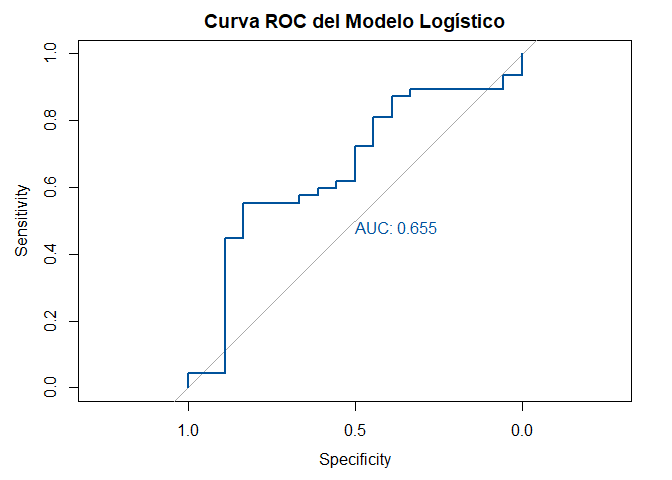

```r
# Graficar la curva con más detalles
plot(roc_curve,
     main = "Curva ROC del Modelo Logístico",
     col = "#00529B",
     lwd = 2,
     print.auc = TRUE) # Muestra el AUC directamente en el gráfico
```

```r
# --- Preparación de variables para el modelo de regresión logística ---
# Se combina el dataframe 'datos' con los terciles de los componentes principales.
# Esto asegura que todas las variables necesarias estén en un solo dataframe para el modelo.

# Preparación de la variable de respuesta 'death' (metástasis)
# Si 'death' no existe en 'datos', se crea a partir de 'extension'.
if (!("death" %in% colnames(datos))) {
  datos$death <- ifelse(datos$extension == "metastasico", 1, 0)
  message("Advertencia: La columna 'death' no se encontró en 'datos'. Se está creando una columna 'death' numérica (1 para 'metastasico', 0 para 'no metastasico') a partir de 'extension'. Reemplaza esto con tu variable de respuesta real para 'death'.")
} else {
  # Asegurarse de que 'death' sea numérica (0/1) para la regresión logística
  datos$death <- as.numeric(datos$death)
}
# Preparación de las variables sociodemográficas/clínicas: 'smk' y 'sex'
if (!("smk" %in% colnames(datos))) {
  datos$smk <- sample(0:2, nrow(datos), replace = TRUE)
  message("Advertencia: La columna 'smk' no se encontró en 'datos'. Se ha creado una columna 'smk' de ejemplo. Reemplaza esto con tus datos reales.")
}
if (!("sex" %in% colnames(datos))) {
  datos$sex <- sample(0:1, nrow(datos), replace = TRUE)
  message("Advertencia: La columna 'sex' no se encontró en 'datos'. Se ha creado una columna 'sex' de ejemplo. Reemplaza esto con tus datos reales.")
}
# Crear el dataframe para regresión logística
df_for_regression <- data.frame(
  death = datos$death,
  smk   = factor(datos$smk, levels = c(0,1,2), labels = c("no fumador","fumador","ex-fumador")),
  sex   = as.factor(datos$sex)
)
# Añadir los terciles de los PCs
for(i in 1:n.pc) {
  tercil_col <- paste0("PC", i, "_tercil")
  if (tercil_col %in% colnames(pca_scores)) {
    df_for_regression[[tercil_col]] <- pca_scores[[tercil_col]]
  } else {
    message("Advertencia: No se encontró '", tercil_col, "' en pca_scores.")
  }
}

# --- DIAGNÓSTICO DE NIVELES DE FACTORES ---
message("\n--- DIAGNÓSTICO: NIVELES DE FACTORES ---")
```

```
##
## --- DIAGNÓSTICO: NIVELES DE FACTORES ---
```

```r
message("sex: ", paste(levels(df_for_regression$sex), collapse = ", "))
```

```
## sex: 0, 1
```

```r
message("smk: ", paste(levels(df_for_regression$smk), collapse = ", "))
```

```
## smk: no fumador, fumador, ex-fumador
```

```r
for(i in 1:n.pc) {
  col <- paste0("PC", i, "_tercil")
  if (col %in% names(df_for_regression)) {
    message(col, ": ", paste(levels(df_for_regression[[col]]), collapse = ", "))
  }
}
```

```
## PC1_tercil: T1, T2, T3
```

```
## PC2_tercil: T1, T2, T3
```

```
## PC3_tercil: T1, T2, T3
```

```
## PC4_tercil: T1, T2, T3
```

```
## PC5_tercil: T1, T2, T3
```

```r
message("--- FIN DIAGNÓSTICO ---")
```

```
## --- FIN DIAGNÓSTICO ---
```

```r
# Construir la fórmula dinámica
pc_terciles <- paste0("PC", 1:n.pc, "_tercil")
pc_exist <- pc_terciles[pc_terciles %in% names(df_for_regression)]
if (length(pc_exist)==0) {
  formula_str <- "death ~ sex + smk"
  message("Sin PCs: modelo sólo con sex y smk.")
} else {
  formula_str <- paste("death ~ sex + smk +", paste(pc_exist, collapse = " + "))
}
message("Fórmula: ", formula_str)
```

```
## Fórmula: death ~ sex + smk + PC1_tercil + PC2_tercil + PC3_tercil + PC4_tercil + PC5_tercil
```

```r
# Ajustar el modelo de regresión logística
tryCatch({
  modelo_logistico <- glm(as.formula(formula_str),
                          data = df_for_regression,
                          family = binomial(link = "logit"))

  # Resumen rápido (opcional)
  message("\n--- Resumen del Modelo Logístico ---")
  summary(modelo_logistico)

  # Intervalos de confianza sobre escala logit (para OR usaremos exponenciación)
  message("\n--- IC 95% en escala logit ---")
  print(confint(modelo_logistico))

  # ============================================================================
  # GENERACIÓN DE LA TABLA ESTILIZADA CON GT PARA REGRESIÓN LOGÍSTICA
  # ============================================================================

  # Formateo de OR e IC
  format_or_ci <- function(or, lower, upper) {
    if (is.na(or) || is.infinite(or)) return("NA (NA a NA)")
    fmt <- function(x) {
      if (abs(x) < 0.001)    formatC(x, format = "e", digits = 2)
      else if (abs(x) >= 1000) formatC(x, format = "e", digits = 2)
      else                    formatC(x, format = "f", digits = 2)
    }
    paste0(fmt(or), " (", fmt(lower), " a ", fmt(upper), ")")
  }
  format_p <- function(p) {
    if (is.na(p)) return("NA")
    if (p < 0.001) return("< 0.001")
    formatC(p, digits = 3, format = "f")
  }

  # Extraer OR con broom (exponentiate = TRUE)
  tabla_log_tidy <- broom::tidy(modelo_logistico,
                                conf.int = TRUE,
                                exponentiate = TRUE)

  # Construir filas para GT
  filas <- list()

  # PCs
  for(i in seq_along(pc_exist)) {
    var <- pc_exist[i]
    niveles <- levels(df_for_regression[[var]])
    if (length(niveles) >= 2) {
      row <- tibble(
        Variable = paste0("Terciles componente ", i),
        T1_OR_IC = paste0("1 (Ref.) - ", niveles[1]),
        T1_P     = "NA",
        T2_OR_IC = NA_character_,
        T2_P     = NA_character_,
        T3_OR_IC = NA_character_,
        T3_P     = NA_character_
      )
      # Nivel 2
      term2 <- paste0(var, niveles[2])
      d2 <- tabla_log_tidy %>% filter(term == term2)
      if (nrow(d2)>0) {
        row$T2_OR_IC <- format_or_ci(d2$estimate, d2$conf.low, d2$conf.high)
        row$T2_P     <- format_p(d2$p.value)
      }
      # Nivel 3
      if (length(niveles)>=3) {
        term3 <- paste0(var, niveles[3])
        d3 <- tabla_log_tidy %>% filter(term == term3)
        if (nrow(d3)>0) {
          row$T3_OR_IC <- format_or_ci(d3$estimate, d3$conf.low, d3$conf.high)
          row$T3_P     <- format_p(d3$p.value)
        }
      }
      filas[[length(filas)+1]] <- row
    }
  }

  # Sexo
  sex_lv <- levels(df_for_regression$sex)
  if (length(sex_lv)>=2) {
    d_sex <- tabla_log_tidy %>% filter(term == paste0("sex", sex_lv[2]))
    fila_sex <- tibble(
      Variable = "Sexo",
      T1_OR_IC = paste0("1 (Ref.) - ", sex_lv[1]),
      T1_P     = "NA",
      T2_OR_IC = if(nrow(d_sex)>0) format_or_ci(d_sex$estimate, d_sex$conf.low, d_sex$conf.high) else NA_character_,
      T2_P     = if(nrow(d_sex)>0) format_p(d_sex$p.value) else NA_character_,
      T3_OR_IC = NA_character_,
      T3_P     = NA_character_
    )
    filas[[length(filas)+1]] <- fila_sex
  }

  # Tabaquismo
  smk_lv <- levels(df_for_regression$smk)
  if (length(smk_lv)>=2) {
    d2 <- tabla_log_tidy %>% filter(term == paste0("smk", smk_lv[2]))
    d3 <- if(length(smk_lv)>=3) tabla_log_tidy %>% filter(term == paste0("smk", smk_lv[3])) else NULL
    fila_smk <- tibble(
      Variable = "Tabaquismo",
      T1_OR_IC = paste0("1 (Ref.) - ", smk_lv[1]),
      T1_P     = "NA",
      T2_OR_IC = if(nrow(d2)>0) format_or_ci(d2$estimate, d2$conf.low, d2$conf.high) else NA_character_,
      T2_P     = if(nrow(d2)>0) format_p(d2$p.value) else NA_character_,
      T3_OR_IC = if(!is.null(d3) && nrow(d3)>0) format_or_ci(d3$estimate, d3$conf.low, d3$conf.high) else NA_character_,
      T3_P     = if(!is.null(d3) && nrow(d3)>0) format_p(d3$p.value) else NA_character_
    )
    filas[[length(filas)+1]] <- fila_smk
  }

  # Unir y crear tabla GT
  df_gt <- bind_rows(filas)
  gt(df_gt) %>%
    cols_label(
      Variable = "",
      T1_OR_IC = md("OR (IC 95%)"),
      T1_P     = md("P value"),
      T2_OR_IC = md("OR (IC 95%)"),
      T2_P     = md("P value"),
      T3_OR_IC = md("OR (IC 95%)"),
      T3_P     = md("P value")
    ) %>%
    tab_spanner(label = "T1", columns = c(T1_OR_IC, T1_P)) %>%
    tab_spanner(label = "T2", columns = c(T2_OR_IC, T2_P)) %>%
    tab_spanner(label = "T3", columns = c(T3_OR_IC, T3_P)) %>%
    tab_header(title = md("Tabla de regresión logística. OR de variables en Metástasis")) %>%
    tab_source_note(md("Nota: Odds ratios e Intervalos de Confianza al 95%. La variable respuesta 'death' codificada 1 (metastásico) vs 0 (no metastásico). Los valores Na para pvalue en t1 se debe a que es la categoría de referencia, por lo que no es estimable.")) %>%
    cols_align(align = "center", columns = everything()) %>%
    tab_options(
      table.border.top.color     = "lightgray",
      table.border.bottom.color  = "lightgray",
      column_labels.background.color = "#E0F2F7",
      heading.background.color       = "#E0F2F7"
    ) %>%
    cols_width(Variable ~ px(200), starts_with("T") ~ px(100))

}, error = function(e) {
  message("Error al ajustar el modelo logístico o generar la tabla: ", e$message)
})
```

```
##
## --- Resumen del Modelo Logístico ---
```

```
##
## --- IC 95% en escala logit ---
```

```
##                    2.5 %      97.5 %
## (Intercept)   -1.0190712  3.65474860
## sex1          -0.9654799  1.81039904
## smkfumador    -2.3418059  1.17344734
## smkex-fumador -2.5896758  0.99311462
## PC1_tercilT2  -1.9490245  1.33094657
## PC1_tercilT3  -1.6402900  2.39881346
## PC2_tercilT2  -1.7719134  2.13213258
## PC2_tercilT3  -1.3012380  1.94750370
## PC3_tercilT2  -1.4225289  1.78998046
## PC3_tercilT3   0.1247212  4.44127100
## PC4_tercilT2  -1.7614724  1.74489771
## PC4_tercilT3  -4.0547889 -0.05319152
## PC5_tercilT2  -2.1901262  1.53941474
## PC5_tercilT3  -1.6853549  1.78918599
```

Tabla de regresión logística. OR de variables en Metástasis

|  | T1 OR (IC 95%) | T1 P value | T2 OR (IC 95%) | T2 P value | T3 OR (IC 95%) | T3 P value |
| --- | --- | --- | --- | --- | --- | --- |
| Terciles componente 1 | 1 (Ref.) - T1 | NA | 0.74 (0.14 a 3.78) | 0.712 | 1.37 (0.19 a 11.01) | 0.754 |
| Terciles componente 2 | 1 (Ref.) - T1 | NA | 1.16 (0.17 a 8.43) | 0.877 | 1.34 (0.27 a 7.01) | 0.719 |
| Terciles componente 3 | 1 (Ref.) - T1 | NA | 1.18 (0.24 a 5.99) | 0.835 | 8.32 (1.13 a 84.88) | 0.050 |
| Terciles componente 4 | 1 (Ref.) - T1 | NA | 1.01 (0.17 a 5.73) | 0.989 | 0.15 (0.02 a 0.95) | 0.058 |
| Terciles componente 5 | 1 (Ref.) - T1 | NA | 0.75 (0.11 a 4.66) | 0.753 | 1.05 (0.19 a 5.98) | 0.956 |
| Sexo | 1 (Ref.) - 0 | NA | 1.52 (0.38 a 6.11) | 0.547 | NA | NA |
| Tabaquismo | 1 (Ref.) - no fumador | NA | 0.58 (0.10 a 3.23) | 0.540 | 0.49 (0.08 a 2.70) | 0.422 |

Nota: Odds ratios e Intervalos de Confianza al 95%. La variable respuesta ‘death’ codificada 1 (metastásico) vs 0 (no metastásico). Los valores Na para pvalue en t1 se debe a que es la categoría de referencia, por lo que no es estimable.